# Classification case: Assessing the performance of remote sensing models

Luciana Nieto & Adrian Correndo

2026-03-18

## 1. Introduction

[figure not shown]

The *`metrica`* package was developed to visualize and compute the level of agreement between observed ground-truth values and model-derived (e.g., mechanistic or empirical) predicted.

This package is intended to fit into the following workflow:

1. a data set containing the observed values is used to train a model
2. the trained model is used to generate predicted
3. a data frame containing at least the **observed** and model-**predicted** values is created
4. *`metrica`* package is used to compute and evaluate the classification model based on observed and predicted values
5. *`metrica`* package is used to visualize model fit and selected fit metrics

This vignette introduces the functionality of the *`metrica`* package applied to observed and model-predicted values of a binary land cover classification scenario, where the two classes are vegetation (1) and non-vegetation (0)).

Let’s begin by loading the packages needed.  
## Libraries

```r
library(metrica)
library(dplyr)
library(purrr)
library(tidyr)
library(ggplot2)
```

## 2. Example datasets

### 2.1. Kansas Land Cover data

```r
# Load
binary_landCover <- metrica::land_cover

# Printing first observations
head(binary_landCover)
```

```
#>   actual predicted
#> 1      0         0
#> 2      1         1
#> 3      1         1
#> 4      0         0
#> 5      0         0
#> 6      1         1
```

### 2.2. Maize Phenology

Now we load the multinomial `maize_phenology` data set, which is also already included with the `metrica` package. This multiclass data set presents 16 different classes corresponding to phenological stages of the maize (*Zea Mays* (L.)) crop.

```r
# Load
multi_maize_phen <- metrica::maize_phenology

# Printing first observations
head(multi_maize_phen)
```

```
#>   actual predicted
#> 1     R1       V18
#> 2     R2        R1
#> 3     R2        R1
#> 4     R2        R2
#> 5     R2        R2
#> 6     R2        R2
```

## 3 Visual assessment of agreement

### 3.1 Confusion matrix

The simplest way to visually assess agreement between observed and predicted classes is with a confusion matrix.

We can use the function `confusion_matrix()` from the *metrica* package.

The function requires specifying:

- the data frame object name (`data` argument)
- the name of the column containing observed values (`obs` argument)
- the name of the column containing predicted values (`pred` argument)

The output of the `confusion_matrix()` function is either a table (`plot = FALSE`) or a `ggplot2` object (`plot = TRUE`) that can be further customized:

### 3.1. Binary

```r
# a. Print
binary_landCover %>% confusion_matrix(obs = actual, pred = predicted,
                                      plot = FALSE,
                                      unit = "count")
```

```
#>          OBSERVED
#> PREDICTED   0   1
#>         0 181   6
#>         1   6  92
```

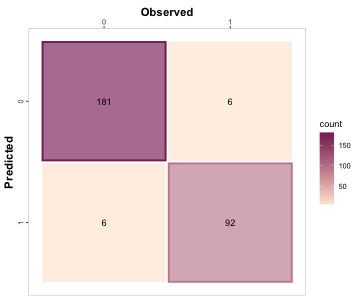

```r
# b. Plot
binary_landCover %>% confusion_matrix(obs = actual, pred = predicted,
                                      plot = TRUE,
                                      colors = c(low="#ffe8d6" , high="#892b64"),
                                      unit = "count")
```

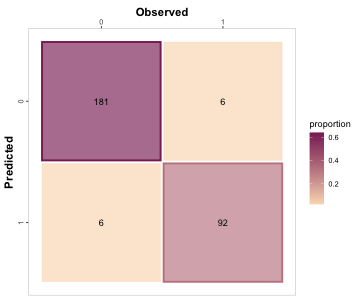

```r
# c. Unit = proportion
binary_landCover %>% confusion_matrix(obs = actual, pred = predicted,
                                      plot = TRUE,
                                      colors = c(low="#f9dbbd" , high="#892b64"),
                                      unit = "proportion")
```

### 3.2. Multiclass

```r
# a. Print
multi_maize_phen %>% confusion_matrix(obs = actual, pred = predicted,
                                      plot = FALSE,
                                      unit = "count")
```

```
#>          OBSERVED
#> PREDICTED R1 R2 R3 R4 R5 R6 V10 V12 V13 V14 V15 V16 V18 V19 V9 VT
#>       R1   0  2  0  0  0  0   0   0   0   0   0   0   0   0  0  0
#>       R2   0  4  0  0  0  0   0   0   0   1   0   0   0   0  0  0
#>       R3   0  1  2  0  0  0   0   0   0   0   0   0   0   0  0  0
#>       R4   0  0  0  6  0  0   0   0   0   0   0   0   0   0  0  0
#>       R5   0  0  0  0 12  1   0   0   0   0   0   0   0   0  0  0
#>       R6   0  0  0  0  3 32   0   0   0   0   0   0   0   0  0  0
#>       V10  0  0  0  0  0  0   6   0   0   1   0   0   0   0  0  0
#>       V12  0  0  0  0  0  0   0   7   1   0   0   0   0   0  0  0
#>       V13  0  0  0  0  0  0   0   0   6   0   0   0   0   0  0  0
#>       V14  0  0  0  0  0  0   0   0   0   2   0   0   0   0  0  0
#>       V15  0  0  0  0  0  0   0   0   0   0   1   0   0   0  0  1
#>       V16  0  0  0  0  0  0   0   0   0   0   0   2   0   0  0  0
#>       V18  1  0  0  0  0  0   0   0   0   0   0   0   4   0  0  0
#>       V19  0  0  0  0  0  0   0   0   0   0   0   0   0   2  0  0
#>       V9   0  0  0  0  0  0   0   0   0   0   0   0   0   0  2  0
#>       VT   0  0  0  0  0  0   0   0   0   0   0   0   0   0  0  3
```

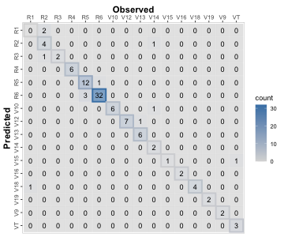

```r
# b. Plot
multi_maize_phen %>% confusion_matrix(obs = actual, pred = predicted,
                                      plot = TRUE,
                                      colors = c(low="grey85" , high="steelblue"),
                                      unit = "count")
```

## 4. Numerical assessment of agreement

A list with all the the classification metrics including their name, definition, details, formula, and function name, please check [here](https://adriancorrendo.github.io/metrica/articles/available_metrics_classification.html).

All of the metric functions take at least three arguments:

- the data frame object name (`data` argument, optional)
- the name of the column containing observed values (`obs` argument)
- the name of the column containing predicted values (`pred` argument)
- an integer (1 or 2) indicating the alphanumerical order of the positive event (`pos_level` argument, Default = 2)
- a TRUE/FALSE indicating to estimate metrics for each single class (`atom` argument, Default = FALSE). This argument is only functional for multiclass datasets.
- a TRUE/FALSE indicating to store the numeric result as a list (`tidy` argument, Default = FALSE), or as a data frame (tidy = TRUE).

### 4.1. Single metrics

The user can choose to calculate a single metric, or to calculate all metrics at once.

To calculate a single metric, the metric function can be called. For example, to calculate $accuracy$, we can use the `accuracy()` function:

```r
# Binary
binary_landCover %>% accuracy(data = ., obs = actual, pred = predicted, tidy = TRUE)
```

```
#>    accuracy
#> 1 0.9578947
```

```r
# Multiclass
maize_phenology %>% accuracy(data = ., obs = actual, pred = predicted, tidy = TRUE)
```

```
#>    accuracy
#> 1 0.8834951
```

Or considering imbalanced observations across classes we can call the `balacc()` function for balanced accuracy:

```r
# Binary
binary_landCover %>% balacc(data = ., obs = actual, pred = predicted, tidy = TRUE)
```

```
#>     balacc
#> 1 0.953345
```

```r
# Multiclass
maize_phenology %>% balacc(data = ., obs = actual, pred = predicted, tidy = TRUE)
```

```
#>      balacc
#> 1 0.9160466
```

Similarly, to calculate precision, we can use the `precision()` function:

```r
# Binary
binary_landCover %>% precision(data = ., obs = actual, pred = predicted, tidy = TRUE)
```

```
#>   precision
#> 1 0.9387755
```

```r
# Multiclass
maize_phenology %>% precision(data = ., obs = actual, pred = predicted, tidy = TRUE)
```

```
#>   precision
#> 1 0.8335108
```

### 4.2. Metrics summary

The user can also calculate all metrics at once using the function `metrics_summary()`:

```r
# Get all at once with metrics_summary()
# Binary
binary_landCover %>% metrics_summary(data = ., obs = actual, pred = predicted, type = "classification")
```

```
#>         Metric        Score
#> 1     accuracy   0.95789474
#> 2   error_rate   0.04210526
#> 3    precision   0.93877551
#> 4       recall   0.93877551
#> 5  specificity   0.96791444
#> 6       balacc   0.95334497
#> 7       fscore   0.93877551
#> 8          agf   0.95323364
#> 9        gmean   0.95323364
#> 10        khat   0.90668995
#> 11         mcc   0.90668995
#> 12         fmi   0.93877551
#> 13         bmi   0.90668995
#> 14         csi   0.32974910
#> 15      deltap   0.90668995
#> 16       posLr  29.25850340
#> 17       negLr   0.06325403
#> 18         dor 462.55555556
#> 19         npv   0.96791444
#> 20         FPR   0.03208556
#> 21         FNR   0.06122449
#> 22         FDR   0.06122449
#> 23         FOR   0.03208556
#> 24      preval   0.34385965
#> 25    preval_t   0.50382084
#> 26     AUC_roc   0.41849817
#> 27          p4   0.95312232
```

```r
# Multiclass
multi_maize_phen %>% metrics_summary(data = ., obs = actual, pred = predicted, type = "classification")
```

[output not shown]

Alternatively, if the user is only looking for specific metrics, within the same function `metrics_summary()`, the user can pass a list of desired metrics using the argument “metrics_list” as follows:

```r
# Get a selected list at once with metrics_summary()
selected_class_metrics <- c("accuracy", "precision", "recall", "fscore")

# Binary
bin_sum <- binary_landCover %>%
  metrics_summary(data = .,
                  obs = actual, pred = predicted,
                  type = "classification",
                  metrics_list = selected_class_metrics, pos_level = 1)

# Multiclass
multi_maize_phen %>%
  metrics_summary(data = .,
                  obs = actual, pred = predicted,
                  type = "classification",
                  metrics_list = selected_class_metrics)
```

[output not shown]

### 4.3. Class wise metrics (`atom` = TRUE)

For multiclass cases, most of the classification metrics can (and should) be estimated at the class level and not simply as an overall average across classes. With the exceptions of kappa (khat), mcc, fmi, and AUC_roc, all classification metrics can be estimated at the class level using the argument `atom = TRUE`, as follows:

```r
# Precision
maize_phenology %>% metrica::precision(obs = actual, pred = predicted, atom = TRUE, tidy = TRUE)
```

```
#>     precision
#> R1  0.0000000
#> R2  0.8000000
#> R3  0.6666667
#> R4  1.0000000
#> R5  0.9230769
#> R6  0.9142857
#> V10 0.8571429
#> V12 0.8750000
#> V13 1.0000000
#> V14 1.0000000
#> V15 0.5000000
#> V16 1.0000000
#> V18 0.8000000
#> V19 1.0000000
#> V9  1.0000000
#> VT  1.0000000
```

```r
# Recall
maize_phenology %>% metrica::recall(obs = actual, pred = predicted, atom = TRUE, tidy = TRUE)
```

```
#>        recall
#> R1  0.0000000
#> R2  0.5714286
#> R3  1.0000000
#> R4  1.0000000
#> R5  0.8000000
#> R6  0.9696970
#> V10 1.0000000
#> V12 1.0000000
#> V13 0.8571429
#> V14 0.5000000
#> V15 1.0000000
#> V16 1.0000000
#> V18 1.0000000
#> V19 1.0000000
#> V9  1.0000000
#> VT  0.7500000
```

```r
# Specificity
maize_phenology %>% metrica::specificity(obs = actual, pred = predicted, atom = TRUE, tidy = TRUE)
```

```
#>          spec
#> R1  0.9803922
#> R2  0.9895833
#> R3  0.9900990
#> R4  1.0000000
#> R5  0.9886364
#> R6  0.9571429
#> V10 0.9896907
#> V12 0.9895833
#> V13 1.0000000
#> V14 1.0000000
#> V15 0.9901961
#> V16 1.0000000
#> V18 0.9898990
#> V19 1.0000000
#> V9  1.0000000
#> VT  1.0000000
```

```r
# atom = TRUE available for more functions available (remove #)
# F-score
# maize_phenology %>% metrica::fscore(obs = actual, pred = predicted, atom = TRUE, tidy = TRUE)
# # Adjusted F-score
# maize_phenology %>% metrica::agf(obs = actual, pred = predicted, atom = TRUE, tidy = TRUE)
# # G-mean
# maize_phenology %>% metrica::gmean(obs = actual, pred = predicted, atom = TRUE, tidy = TRUE)
# # Negative predictive value
# maize_phenology %>% metrica::npv(obs = actual, pred = predicted, atom = TRUE, tidy = TRUE)
# # Prevalence
# maize_phenology %>% metrica::preval(obs = actual, pred = predicted, atom = TRUE, tidy = TRUE)
# # Prevalence threshold
# maize_phenology %>% metrica::preval_t(obs = actual, pred = predicted, atom = TRUE, tidy = TRUE)
# # False omission rate
# maize_phenology %>% metrica::FOR(obs = actual, pred = predicted, atom = TRUE, tidy = TRUE)
# # False detection rate
# maize_phenology %>% metrica::FDR(obs = actual, pred = predicted, atom = TRUE, tidy = TRUE)
# # False positive rate
# maize_phenology %>% metrica::FPR(obs = actual, pred = predicted, atom = TRUE, tidy = TRUE)
# # Falase negative rate
# maize_phenology %>% metrica::FNR(obs = actual, pred = predicted, atom = TRUE, tidy = TRUE)
# # Delta-p
# maize_phenology %>% metrica::deltap(obs = actual, pred = predicted, atom = TRUE, tidy = TRUE)
# # Critical Success Index
# maize_phenology %>% metrica::csi(obs = actual, pred = predicted, atom = TRUE, tidy = TRUE)
# # Bookmaker Informedness
# maize_phenology %>% metrica::bmi(obs = actual, pred = predicted, atom = TRUE, tidy = TRUE)
# # Positive likelihood ratio
# maize_phenology %>% metrica::posLr(obs = actual, pred = predicted, atom = TRUE, tidy = TRUE)
# # Negative likelihood ratio
# maize_phenology %>% metrica::negLr(obs = actual, pred = predicted, atom = TRUE, tidy = TRUE)
# # Diagnostic odds ratio
# maize_phenology %>% metrica::dor(obs = actual, pred = predicted, atom = TRUE, tidy = TRUE)
```

### 4.4. Multiple models

In some cases, multiple runs of a model are available to compare vs. observed values (e.g. cross-validation folds). Thus, we can also fit the agreement analysis for several datasets as follows:

```r
set.seed(15)
# Let's simulated two extra runs of the same model for Land Cover
fold_2 <- data.frame(actual = sample(c(0,1), 285, replace = TRUE),
                     predicted = sample(c(0,1), 285, replace = TRUE))
fold_3 <- data.frame(actual = sample(c(0,1), 285, replace = TRUE),
                     predicted = sample(c(0,1), 285, replace = TRUE))

# a. Create nested df with the folds
binary_nested_folds <- bind_rows(list(fold_1 = binary_landCover,
                                      fold_2 = fold_2,
                                      fold_3 = fold_3),
                             .id = "id") %>%
  dplyr::group_by(id) %>% tidyr::nest()

head(binary_nested_folds %>% group_by(id) %>% dplyr::slice_head(n=2))
```

```
#> # A tibble: 3 × 2
#> # Groups:   id [3]
#>   id     data
#>   <chr>  <list>
#> 1 fold_1 <tibble [285 × 2]>
#> 2 fold_2 <tibble [285 × 2]>
#> 3 fold_3 <tibble [285 × 2]>
```

```r
# b. Run
binary_folds_summary <- binary_nested_folds %>%
  # Store metrics in new.column "performance"
  dplyr::mutate(performance =
                  purrr::map(data,
                             ~metrica::metrics_summary(data = .,
                                                       obs = actual, pred = predicted,
                                                       type = "classification"))) %>%
  dplyr::select(-data) %>%
  tidyr::unnest(cols = performance) %>%
  dplyr::arrange(Metric)

head(binary_folds_summary)
```

```
#> # A tibble: 6 × 3
#> # Groups:   id [3]
#>   id     Metric   Score
#>   <chr>  <chr>    <dbl>
#> 1 fold_1 AUC_roc 0.418
#> 2 fold_2 AUC_roc 0.446
#> 3 fold_3 AUC_roc 0.513
#> 4 fold_1 FDR     0.0612
#> 5 fold_2 FDR     0.620
#> 6 fold_3 FDR     0.471
```

#### 4.4.1. Non-nested data

#### 4.4.1.1. Using `group_map()`

```r
non_nested_folds <- binary_nested_folds %>% unnest(cols = "data")

# Using group_map()
binary_folds_summary_2 <- non_nested_folds %>%
  dplyr::group_by(id) %>%
  dplyr::group_map(~metrics_summary(data = ., obs = actual, pred = predicted, type = "classification"))

binary_folds_summary_2
```

```
#> [[1]]
#>         Metric        Score
#> 1     accuracy   0.95789474
#> 2   error_rate   0.04210526
#> 3    precision   0.93877551
#> 4       recall   0.93877551
#> 5  specificity   0.96791444
#> 6       balacc   0.95334497
#> 7       fscore   0.93877551
#> 8          agf   0.95323364
#> 9        gmean   0.95323364
#> 10        khat   0.90668995
#> 11         mcc   0.90668995
#> 12         fmi   0.93877551
#> 13         bmi   0.90668995
```

[output cut: 74 more lines]

```r
# Using summarise()
binary_folds_summary_3 <- non_nested_folds %>%
  dplyr::group_by(id) %>%
  dplyr::reframe(metrics_summary(obs = actual, pred = predicted, type = "classification")) %>%
  dplyr::arrange(Metric)

binary_folds_summary_3
```

```
#> # A tibble: 81 × 3
#>    id     Metric   Score
#>    <chr>  <chr>    <dbl>
#>  1 fold_1 AUC_roc 0.418
#>  2 fold_2 AUC_roc 0.446
#>  3 fold_3 AUC_roc 0.513
#>  4 fold_1 FDR     0.0612
#>  5 fold_2 FDR     0.620
#>  6 fold_3 FDR     0.471
#>  7 fold_1 FNR     0.0612
#>  8 fold_2 FNR     0.594
#>  9 fold_3 FNR     0.493
#> 10 fold_1 FOR     0.0321
#> # ℹ 71 more rows
```

## 5. Visual Assessment

### 5.1. Customizing the confusion matrix

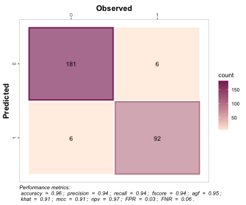

```r
selected_metrics <- c("accuracy", "precision", "recall", "khat",
                   "mcc", "fscore", "agf", "npv", "FPR", "FNR")

binary_matrix_metrics <-
  binary_landCover %>%
  confusion_matrix(obs = actual, pred = predicted,
                   plot = TRUE,
                   colors = c(low="#ffe8d6" , high="#892b64"),
                   unit = "count",
                   # Print metrics_summary
                   print_metrics = TRUE,
                   # List of performance metrics
                   metrics_list = selected_metrics,
                   # Position (bottom or top)
                   position_metrics = "bottom")

binary_matrix_metrics
```

```r
multinomial_matrix_metrics <-
  maize_phenology %>%
  confusion_matrix(obs = actual, pred = predicted,
                   plot = TRUE,
                   colors = c(low="grey85" , high="steelblue"),
                   unit = "count",
                   # Print metrics_summary
                   print_metrics = TRUE,
                   # List of performance metrics
                   metrics_list = selected_metrics,
                   # Position (bottom or top)
                   position_metrics = "bottom")
```

[output not shown]

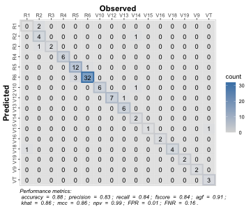

```r
multinomial_matrix_metrics
```

Also, as a ggplot element, outputs are flexible of further edition:

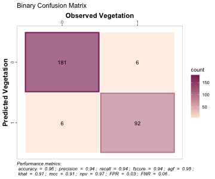

```r
binary_matrix_metrics +
  # Modify labels
  ggplot2::labs(x = "Observed Vegetation",
       y = "Predicted Vegetation",
       title = "Binary Confusion Matrix")
```

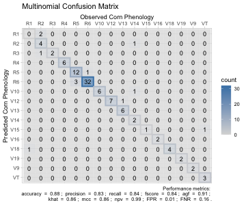

```r
multinomial_matrix_metrics +
  # Modify labels
  ggplot2::labs(x = "Observed Corn Phenology",
       y = "Predicted Corn Phenology",
       title = "Multinomial Confusion Matrix")+
  # Modify theme
  ggplot2::theme_light()
```

## 6. Exporting

To export the metrics summary table, the user can simply write it to file with the function `write.csv()`:

```r
metrics_summary(data = binary_landCover,
                obs = actual,
                pred = predicted,
                type = "classification") %>%
  write.csv("binary_landcover_metrics_summary.csv")
```

Similarly, to export a plot, the user can simply write it to file with the function `ggsave()`:

```r
ggsave(plot = multinomial_matrix_metrics,
       "multinomial_matrix_metrics.png",
       width = 8,
       height = 7)
```